# Data Science Problems

## 3. Data Wrangling

Data set of people is based names on the [1990 Census](https://catalog.data.gov/dataset/names-from-census-1990) and state population by age estimated from Census [factfinder](https://factfinder.census.gov).

```r
load('sample_people.Rda')
```

### 3.1 Update the data frame (sample_people)

Separate the person’s name into a first and last name column.

- Try with strsplit() and lapply() functions to select the appropriate element.

```r
split <- strsplit(sample_people$Name, ', ', fixed = TRUE)

lst <- unlist(split, use.names = FALSE)
m <- matrix(lst, nrow = 5000, byrow = T)
colnames(m) <- c('First_Name', 'Last_Name')
first <- m[, c('First_Name')]
last <- m[, c('Last_Name')]
df <- sample_people[, !(names(sample_people) %in% c('Name'))]
df$First_Name <- first
df$Last_Name <- last
```

- Now try with the tidyr package using the separate() function.

```r
library(tidyr)
df <- separate(sample_people, Name, c('LastName', 'FirstName'), ', ', remove = T)
```

- Show results with the head() function

```r
head(df)
```

```
##     LastName FirstName          State Age_Group Male Age
## 1  CARPENTER     LYNNE        Florida age35to39    1  35
## 2     TAYLOR     JESUS     California age20to24    0  24
## 3   BUCHANAN    ARTHUR        Florida age60to64    0  62
## 4     REEVES     SUSAN North Carolina age15to19    1  18
## 5 YOUNGBLOOD      GARY     California age20to24    0  20
## 6      AYRES     STACY      Minnesota age25to29    1  28
```

### 3.2 Create a summary table by state.

Recommend using the dplyr package with group_by() and summarize() functions.

- What is the sample average and median population by state? Give both the frequency and relative frequency of the stats using inline code on a rmarkdown table:

```r
library(dplyr)
g <- group_by(sample_people, State)
c <- as.data.frame(table(g$State, dnn = "State"), responseName = "Pop")
stat1 <- mean(c$Pop)
stat2 <- median(c$Pop)

r_freq <- function(x){x/5000}
c$R_Freq <- sapply(c$Pop, r_freq)
stat3 <- mean(c$R_Freq)
stat4 <- median(c$R_Freq)
```

| Statistic | Average | Median |
| --- | --- | --- |
| Frequency | **96.1538462** | **60** |
| Relative Frequency | **0.0192308** | **0.012** |

- Order the summary table from largest to smallest population.

```r
ordered <- c[order(c$Pop, decreasing = T),]
```

- [Add a html table](https://rmarkdown.rstudio.com/lesson-7.html) of the 5 larges states using kable()

```r
library(knitr)
kable(ordered[1:5,], caption = "Top 5 Populations")
```

Top 5 Populations

|  | State | Pop | R_Freq |
| --- | --- | --- | --- |
| 5 | California | 647 | 0.1294 |
| 45 | Texas | 418 | 0.0836 |
| 10 | Florida | 307 | 0.0614 |
| 33 | New York | 306 | 0.0612 |
| 14 | Illinois | 222 | 0.0444 |

- Add a plot of all the state populations using plot()

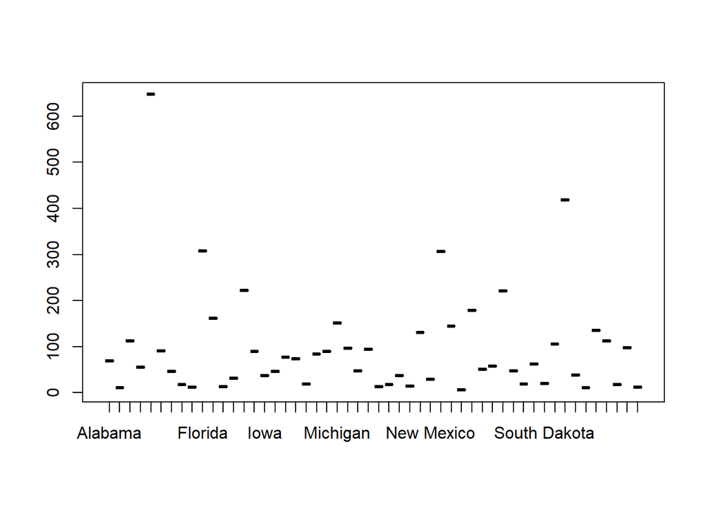

```r
plot(ordered$State, ordered$Pop, "h")
```

- Describe the sample population data based on the table and the plot including the probability of an individual in the sample being from California.

**The sample population data shows that there was a higher number of individuals from California more than any other state. The propbability of an individual being from California is approximately 12.94%. Since California is the most populus state, this is to be expected based from our sample.**

### 3.3 Add the R default data state.name & state.region

- Create reference data frame with state.name & state.region
- Add the region to the sample_people data frame with the merge() function.
- Sample one person, what is his/her percentile based on their age?
- For that person, what is his/her percentile based on their age for his/her region?
- For that person, what is his/her percentile based on their age for his/her state?
- Using the mutate(), create columns for each persons age percentile for US, their region and their state. Validate calculation based on the person sampled.